# Coursera Practical Machine Learning Class - Project

Loïc BERTHOU

August 23, 2015

## Executive Summary

This document aims at demonstrating how we can use devices such as Jawbone Up, Nike FuelBand, and Fitbit in order to track the quality of exercises instead of quantity like it is the case most of the time. In our specific case, we are trying to predict if an athlete has perform barbell lifts correctly or incorrectly.

## Data

The training data for this project are available here:

https://d396qusza40orc.cloudfront.net/predmachlearn/pml-training.csv

The test data are available here:

https://d396qusza40orc.cloudfront.net/predmachlearn/pml-testing.csv

The data for this project come from this source: http://groupware.les.inf.puc-rio.br/har.

## Data Cleaning

We will start by loading the *training* and *testing* datasets.

```r
trainingSet = read.csv("pml-training.csv", header = TRUE, stringsAsFactors = FALSE, na.strings = c("", "#DIV/0!", "NA"))
testingSet = read.csv("pml-testing.csv", header = TRUE, stringsAsFactors = FALSE, na.strings = c("", "#DIV/0!", "NA"))
```

Let’s have a brief overview of them.

```r
str(trainingSet)
```

```
## 'data.frame':    19622 obs. of  160 variables:
##  $ X                       : int  1 2 3 4 5 6 7 8 9 10 ...
##  $ user_name               : chr  "carlitos" "carlitos" "carlitos" "carlitos" ...
##  $ raw_timestamp_part_1    : int  1323084231 1323084231 1323084231 1323084232 1323084232 1323084232 1323084232 1323084232 1323084232 1323084232 ...
##  $ raw_timestamp_part_2    : int  788290 808298 820366 120339 196328 304277 368296 440390 484323 484434 ...
##  $ cvtd_timestamp          : chr  "05/12/2011 11:23" "05/12/2011 11:23" "05/12/2011 11:23" "05/12/2011 11:23" ...
##  $ new_window              : chr  "no" "no" "no" "no" ...
##  $ num_window              : int  11 11 11 12 12 12 12 12 12 12 ...
##  $ roll_belt               : num  1.41 1.41 1.42 1.48 1.48 1.45 1.42 1.42 1.43 1.45 ...
##  $ pitch_belt              : num  8.07 8.07 8.07 8.05 8.07 8.06 8.09 8.13 8.16 8.17 ...
##  $ yaw_belt                : num  -94.4 -94.4 -94.4 -94.4 -94.4 -94.4 -94.4 -94.4 -94.4 -94.4 ...
##  $ total_accel_belt        : int  3 3 3 3 3 3 3 3 3 3 ...
##  $ kurtosis_roll_belt      : num  NA NA NA NA NA NA NA NA NA NA ...
##  $ kurtosis_picth_belt     : num  NA NA NA NA NA NA NA NA NA NA ...
##  $ kurtosis_yaw_belt       : logi  NA NA NA NA NA NA ...
```

[output cut: 86 more lines]

```r
str(testingSet)
```

```
## 'data.frame':    20 obs. of  160 variables:
##  $ X                       : int  1 2 3 4 5 6 7 8 9 10 ...
##  $ user_name               : chr  "pedro" "jeremy" "jeremy" "adelmo" ...
##  $ raw_timestamp_part_1    : int  1323095002 1322673067 1322673075 1322832789 1322489635 1322673149 1322673128 1322673076 1323084240 1322837822 ...
##  $ raw_timestamp_part_2    : int  868349 778725 342967 560311 814776 510661 766645 54671 916313 384285 ...
##  $ cvtd_timestamp          : chr  "05/12/2011 14:23" "30/11/2011 17:11" "30/11/2011 17:11" "02/12/2011 13:33" ...
##  $ new_window              : chr  "no" "no" "no" "no" ...
##  $ num_window              : int  74 431 439 194 235 504 485 440 323 664 ...
##  $ roll_belt               : num  123 1.02 0.87 125 1.35 -5.92 1.2 0.43 0.93 114 ...
##  $ pitch_belt              : num  27 4.87 1.82 -41.6 3.33 1.59 4.44 4.15 6.72 22.4 ...
##  $ yaw_belt                : num  -4.75 -88.9 -88.5 162 -88.6 -87.7 -87.3 -88.5 -93.7 -13.1 ...
##  $ total_accel_belt        : int  20 4 5 17 3 4 4 4 4 18 ...
##  $ kurtosis_roll_belt      : logi  NA NA NA NA NA NA ...
##  $ kurtosis_picth_belt     : logi  NA NA NA NA NA NA ...
##  $ kurtosis_yaw_belt       : logi  NA NA NA NA NA NA ...
```

[output cut: 86 more lines]

Our initial exploratory data analysis shows that some columns contain N/A values. Let’s first count these N/A values.

```r
isNaMatrixTraining <- apply(trainingSet, 1, is.na)
countNaMatrixTraining <- apply(isNaMatrixTraining, 1, sum)
countNaMatrixTraining <- as.data.frame(countNaMatrixTraining)
countNaMatrixTraining
```

```
##                          countNaMatrixTraining
## X                                            0
## user_name                                    0
## raw_timestamp_part_1                         0
## raw_timestamp_part_2                         0
## cvtd_timestamp                               0
## new_window                                   0
## num_window                                   0
## roll_belt                                    0
## pitch_belt                                   0
## yaw_belt                                     0
## total_accel_belt                             0
## kurtosis_roll_belt                       19226
## kurtosis_picth_belt                      19248
## kurtosis_yaw_belt                        19622
## skewness_roll_belt                       19225
## skewness_roll_belt.1                     19248
## skewness_yaw_belt                        19622
## max_roll_belt                            19216
## max_picth_belt                           19216
## max_yaw_belt                             19226
## min_roll_belt                            19216
## min_pitch_belt                           19216
## min_yaw_belt                             19226
## amplitude_roll_belt                      19216
## amplitude_pitch_belt                     19216
## amplitude_yaw_belt                       19226
## var_total_accel_belt                     19216
## avg_roll_belt                            19216
## stddev_roll_belt                         19216
## var_roll_belt                            19216
## avg_pitch_belt                           19216
## stddev_pitch_belt                        19216
## var_pitch_belt                           19216
## avg_yaw_belt                             19216
## stddev_yaw_belt                          19216
## var_yaw_belt                             19216
## gyros_belt_x                                 0
## gyros_belt_y                                 0
## gyros_belt_z                                 0
```

[output cut: 106 more lines]

```
## stddev_pitch_forearm                     19216
## var_pitch_forearm                        19216
## avg_yaw_forearm                          19216
## stddev_yaw_forearm                       19216
## var_yaw_forearm                          19216
## gyros_forearm_x                              0
## gyros_forearm_y                              0
## gyros_forearm_z                              0
## accel_forearm_x                              0
## accel_forearm_y                              0
## accel_forearm_z                              0
## magnet_forearm_x                             0
## magnet_forearm_y                             0
## magnet_forearm_z                             0
## classe                                       0
```

```r
isNaMatrixTesting <- apply(testingSet, 1, is.na)
countNaMatrixTesting <- apply(isNaMatrixTesting, 1, sum)
countNaMatrixTesting <- as.data.frame(countNaMatrixTesting)
countNaMatrixTesting
```

```
##                          countNaMatrixTesting
## X                                           0
## user_name                                   0
## raw_timestamp_part_1                        0
## raw_timestamp_part_2                        0
## cvtd_timestamp                              0
## new_window                                  0
## num_window                                  0
## roll_belt                                   0
## pitch_belt                                  0
## yaw_belt                                    0
## total_accel_belt                            0
## kurtosis_roll_belt                         20
## kurtosis_picth_belt                        20
## kurtosis_yaw_belt                          20
## skewness_roll_belt                         20
## skewness_roll_belt.1                       20
## skewness_yaw_belt                          20
## max_roll_belt                              20
## max_picth_belt                             20
## max_yaw_belt                               20
## min_roll_belt                              20
## min_pitch_belt                             20
## min_yaw_belt                               20
## amplitude_roll_belt                        20
## amplitude_pitch_belt                       20
## amplitude_yaw_belt                         20
## var_total_accel_belt                       20
## avg_roll_belt                              20
## stddev_roll_belt                           20
## var_roll_belt                              20
## avg_pitch_belt                             20
## stddev_pitch_belt                          20
## var_pitch_belt                             20
## avg_yaw_belt                               20
## stddev_yaw_belt                            20
## var_yaw_belt                               20
## gyros_belt_x                                0
## gyros_belt_y                                0
## gyros_belt_z                                0
```

[output cut: 106 more lines]

```
## stddev_pitch_forearm                       20
## var_pitch_forearm                          20
## avg_yaw_forearm                            20
## stddev_yaw_forearm                         20
## var_yaw_forearm                            20
## gyros_forearm_x                             0
## gyros_forearm_y                             0
## gyros_forearm_z                             0
## accel_forearm_x                             0
## accel_forearm_y                             0
## accel_forearm_z                             0
## magnet_forearm_x                            0
## magnet_forearm_y                            0
## magnet_forearm_z                            0
## problem_id                                  0
```

Since the number of N/A values is non-neglectable, we’re going to remove all these columns.

```r
# Combine the columns that contain N/A values.
noNaMatrix <- as.data.frame(cbind(countNaMatrixTraining[,1] == 0, countNaMatrixTesting[,1] == 0))
names(noNaMatrix) <- c("training", "testing")
noNaMatrix$combined <- noNaMatrix$training & noNaMatrix$testing

trainingSetClean <- trainingSet[, noNaMatrix$combined]
testingSetClean <- testingSet[, noNaMatrix$combined]
```

We will also remove the timestamp columns that will not be used in the analysis.

```r
trainingSetClean <- subset(trainingSetClean, select=-c(X, user_name, raw_timestamp_part_1, raw_timestamp_part_2, cvtd_timestamp, new_window, num_window))
testingSetClean <- subset(testingSetClean, select=-c(X, user_name, raw_timestamp_part_1, raw_timestamp_part_2, cvtd_timestamp, new_window, num_window))
```

Now we will make the factor variables as factor columns.

```r
trainingSetClean$classe <- as.factor(trainingSetClean$classe)
```

## Data Modeling

We first load the libraries for machine learning and parallelization (to set-up our system to use multiple cores).

```r
library(caret)
library(doParallel)
library(randomForest)

# Create the cluster of workers
cl <- makeCluster(detectCores())
registerDoParallel(cl)
```

### Sub-Sampling

Since we know that our training set contains many observations (19622 rows), we fear that the training algorithm would take a long time. We will then first use a small sample of the original training sample to investigate the best model to use in our machine learning algorithm.

```r
# Sub-sampling 2000 rows randomly
sample1 <- trainingSetClean[sample(1:nrow(trainingSetClean), 2000, replace=FALSE),]

# Creating the training and testing data partitions (75% training)
dataPartitions <- createDataPartition(sample1$classe, p=0.75, list=FALSE)
training1 <- sample1[dataPartitions[, 1], ]
testing1 <- sample1[-dataPartitions[, 1], ]

# Checking the size our new sub datasets
dim(training1)
```

```
## [1] 1501   53
```

```r
dim(testing1)
```

```
## [1] 499  53
```

### The model is being generated with the ‘Random Forest’ method.

```r
timeRf.start <- Sys.time()
#fitRfControl <- trainControl(method = "cv", number = 5)
#fitRf <- train(classe ~ ., data = training1, method = "rf", trControl = fitRfControl, prox = TRUE)
fitRf <- randomForest(classe ~ ., data = training1)
timeRf.end <- Sys.time()
timeRf.taken <- timeRf.end - timeRf.start
fitRf
```

```
##
## Call:
##  randomForest(formula = classe ~ ., data = training1)
##                Type of random forest: classification
##                      Number of trees: 500
## No. of variables tried at each split: 7
##
##         OOB estimate of  error rate: 6.6%
## Confusion matrix:
##     A   B   C   D   E class.error
## A 439   3   1   3   0  0.01569507
## B  18 254  12   4   0  0.11805556
## C   1  19 242   3   0  0.08679245
## D   3   1  14 216   3  0.08860759
## E   1   2   6   5 251  0.05283019
```

```r
timeRf.taken
```

```
## Time difference of 2.581014 secs
```

Let’s predict the values on the sub-testing sample anc compare them to the reference.

```r
predictRf <- predict(fitRf, testing1)
confRf <- confusionMatrix(predictRf, testing1$classe)
confRf
```

```
## Confusion Matrix and Statistics
##
##           Reference
## Prediction   A   B   C   D   E
##          A 146   8   0   1   0
##          B   1  86   6   0   3
##          C   1   2  82   4   3
##          D   0   0   0  74   1
##          E   0   0   0   0  81
##
## Overall Statistics
##
##                Accuracy : 0.9399
##                  95% CI : (0.9153, 0.9591)
##     No Information Rate : 0.2966
##     P-Value [Acc > NIR] : < 2.2e-16
##
##                   Kappa : 0.9235
##  Mcnemar's Test P-Value : NA
##
## Statistics by Class:
##
##                      Class: A Class: B Class: C Class: D Class: E
## Sensitivity            0.9865   0.8958   0.9318   0.9367   0.9205
## Specificity            0.9744   0.9752   0.9757   0.9976   1.0000
## Pos Pred Value         0.9419   0.8958   0.8913   0.9867   1.0000
## Neg Pred Value         0.9942   0.9752   0.9853   0.9882   0.9833
## Prevalence             0.2966   0.1924   0.1764   0.1583   0.1764
## Detection Rate         0.2926   0.1723   0.1643   0.1483   0.1623
## Detection Prevalence   0.3106   0.1924   0.1844   0.1503   0.1623
## Balanced Accuracy      0.9804   0.9355   0.9537   0.9672   0.9602
```

With this small sample, the model was generated quite fast (2.6 seconds) and we already have an accuracy rate of 94.0% with a 95% confidence interval between 91.5% and 95.9% ! This one looks like our winner but let’s still investigate other methods.

### The model is being generated with the Caret package and the ‘Boosted Tree’ method.

```r
timeGbm.start <- Sys.time()
fitGmbControl <- trainControl(method = "repeatedcv", number = 5, repeats = 5)
fitGbm <- train(classe ~ ., data = training1, method = "gbm", trControl = fitGmbControl, verbose = FALSE)
timeGbm.end <- Sys.time()
timeGbm.taken <- timeGbm.end - timeGbm.start
fitGbm
```

```
## Stochastic Gradient Boosting
##
## 1501 samples
##   52 predictor
##    5 classes: 'A', 'B', 'C', 'D', 'E'
##
## No pre-processing
## Resampling: Cross-Validated (5 fold, repeated 5 times)
## Summary of sample sizes: 1200, 1202, 1201, 1200, 1201, 1200, ...
## Resampling results across tuning parameters:
##
##   interaction.depth  n.trees  Accuracy   Kappa      Accuracy SD
##   1                   50      0.7244308  0.6480345  0.02009674
##   1                  100      0.7842535  0.7252866  0.02172684
##   1                  150      0.8169009  0.7669459  0.01921312
##   2                   50      0.8031830  0.7493338  0.02065144
##   2                  100      0.8531505  0.8131911  0.01652311
##   2                  150      0.8764565  0.8429414  0.02077935
##   3                   50      0.8467531  0.8049268  0.01679092
##   3                  100      0.8807316  0.8482797  0.02334487
##   3                  150      0.8973868  0.8695192  0.02196041
##   Kappa SD
##   0.02549927
##   0.02775004
##   0.02451942
##   0.02637324
##   0.02103748
##   0.02653682
##   0.02147073
##   0.02984203
##   0.02800611
##
## Tuning parameter 'shrinkage' was held constant at a value of 0.1
##
## Tuning parameter 'n.minobsinnode' was held constant at a value of 10
## Accuracy was used to select the optimal model using  the largest value.
## The final values used for the model were n.trees = 150,
##  interaction.depth = 3, shrinkage = 0.1 and n.minobsinnode = 10.
```

```r
timeGbm.taken
```

```
## Time difference of 41.93362 secs
```

Let’s predict the values on the sub-testing sample and compare them to the reference.

```r
predictGbm <- predict(fitGbm, testing1)
confGbm <- confusionMatrix(predictGbm, testing1$classe)
confGbm
```

```
## Confusion Matrix and Statistics
##
##           Reference
## Prediction   A   B   C   D   E
##          A 144   5   0   0   0
##          B   2  89   8   0   6
##          C   1   2  77   3   4
##          D   1   0   3  75   1
##          E   0   0   0   1  77
##
## Overall Statistics
##
##                Accuracy : 0.9259
##                  95% CI : (0.8992, 0.9473)
##     No Information Rate : 0.2966
##     P-Value [Acc > NIR] : < 2.2e-16
##
##                   Kappa : 0.9058
##  Mcnemar's Test P-Value : NA
##
## Statistics by Class:
##
##                      Class: A Class: B Class: C Class: D Class: E
## Sensitivity            0.9730   0.9271   0.8750   0.9494   0.8750
## Specificity            0.9858   0.9603   0.9757   0.9881   0.9976
## Pos Pred Value         0.9664   0.8476   0.8851   0.9375   0.9872
## Neg Pred Value         0.9886   0.9822   0.9733   0.9905   0.9739
## Prevalence             0.2966   0.1924   0.1764   0.1583   0.1764
## Detection Rate         0.2886   0.1784   0.1543   0.1503   0.1543
## Detection Prevalence   0.2986   0.2104   0.1743   0.1603   0.1563
## Balanced Accuracy      0.9794   0.9437   0.9253   0.9687   0.9363
```

This method is slower (41.9 seconds) and the accuracy rate is below the previous method at 92.6% with a 95% confidence interval between 89.9% and 94.7%.

### The model is being generated with the Caret package and the ‘Prediction Tree’ method.

```r
timeRpart.start <- Sys.time()
fitRpart <- train(classe ~ ., method="rpart", data=training1)
timeRpart.end <- Sys.time()
timeRpart.taken <- timeRpart.end - timeRpart.start
print(fitRpart$finalModel)
```

```
## n= 1501
##
## node), split, n, loss, yval, (yprob)
##       * denotes terminal node
##
##  1) root 1501 1055 A (0.3 0.19 0.18 0.16 0.18)
##    2) roll_belt< 130.5 1394  950 A (0.32 0.21 0.19 0.17 0.11)
##      4) pitch_forearm< -34.25 114    0 A (1 0 0 0 0) *
##      5) pitch_forearm>=-34.25 1280  950 A (0.26 0.22 0.21 0.19 0.12)
##       10) magnet_dumbbell_y< 434.5 1072  746 A (0.3 0.16 0.24 0.18 0.12)
##         20) roll_forearm< 124.5 655  363 A (0.45 0.16 0.17 0.16 0.061) *
##         21) roll_forearm>=124.5 417  277 C (0.082 0.17 0.34 0.22 0.2) *
##       11) magnet_dumbbell_y>=434.5 208   92 B (0.019 0.56 0.058 0.19 0.17) *
##    3) roll_belt>=130.5 107    2 E (0.019 0 0 0 0.98) *
```

```r
timeRpart.taken
```

```
## Time difference of 1.855007 secs
```

Let’s predict the values on the sub-testing sample anc compare them to the reference.

```r
predictRpart <- predict(fitRpart, testing1)
confRpart <- confusionMatrix(predictRpart, testing1$classe)
confRpart
```

```
## Confusion Matrix and Statistics
##
##           Reference
## Prediction   A   B   C   D   E
##          A 137  38  39  38  13
##          B   3  35   3  17   8
##          C   7  23  46  24  27
##          D   0   0   0   0   0
##          E   1   0   0   0  40
##
## Overall Statistics
##
##                Accuracy : 0.517
##                  95% CI : (0.4722, 0.5617)
##     No Information Rate : 0.2966
##     P-Value [Acc > NIR] : < 2.2e-16
##
##                   Kappa : 0.3626
##  Mcnemar's Test P-Value : NA
##
## Statistics by Class:
##
##                      Class: A Class: B Class: C Class: D Class: E
## Sensitivity            0.9257  0.36458  0.52273   0.0000  0.45455
## Specificity            0.6353  0.92308  0.80292   1.0000  0.99757
## Pos Pred Value         0.5170  0.53030  0.36220      NaN  0.97561
## Neg Pred Value         0.9530  0.85912  0.88710   0.8417  0.89520
## Prevalence             0.2966  0.19238  0.17635   0.1583  0.17635
## Detection Rate         0.2745  0.07014  0.09218   0.0000  0.08016
## Detection Prevalence   0.5311  0.13226  0.25451   0.0000  0.08216
## Balanced Accuracy      0.7805  0.64383  0.66282   0.5000  0.72606
```

This method is fast (1.9 seconds) but the accuracy rate is bad at 51.7% with a 95% confidence interval between 47.2% and 56.2%.

### Choosing the model

After trying out a few different models, the **Random Forest** seems like the most accurate. We will then run the training on the whole training set to create the final model used for our prediction.

We will first divide our origianl training set into two parts for the training and final validation. We are using 85% of the original training set for training and the 15% left will be used for cross validation.

```r
inTrain <- createDataPartition(trainingSetClean$classe, p = 0.85, list = FALSE)
trainingSetRf <- trainingSetClean[inTrain, ]
validationSetRf <- trainingSetClean[-inTrain, ]

time.start <- Sys.time()
# I am calling the randomForest function directly because the train() function makes it too slow
#fitControl <- trainControl(method = "cv", number = 5)
#fit <- train(classe ~ ., data = trainingSetRf, method = "rf", trControl = fitControl, ntree = 10)
fit <- randomForest(classe ~ ., data = trainingSetRf, ntree = 500)
time.end <- Sys.time()
time.taken <- time.end - time.start
fit
```

```
##
## Call:
##  randomForest(formula = classe ~ ., data = trainingSetRf, ntree = 500)
##                Type of random forest: classification
##                      Number of trees: 500
## No. of variables tried at each split: 7
##
##         OOB estimate of  error rate: 0.32%
## Confusion matrix:
##      A    B    C    D    E class.error
## A 4741    2    0    0    0 0.000421674
## B   10 3215    3    0    0 0.004027261
## C    0   14 2894    1    0 0.005156411
## D    0    0   14 2718    2 0.005852231
## E    0    0    1    7 3058 0.002609263
```

```r
time.taken
```

```
## Time difference of 40.22701 secs
```

```r
# Good practice to shut down the workers.
stopCluster(cl)
```

Now we can predict the class for the validation dataset.

```r
validationSetRf$prediction <- predict(fit, validationSetRf)
confFit <- confusionMatrix(validationSetRf$prediction, validationSetRf$classe)
confFit
```

```
## Confusion Matrix and Statistics
##
##           Reference
## Prediction   A   B   C   D   E
##          A 837   2   0   0   0
##          B   0 566   4   0   0
##          C   0   1 509   4   0
##          D   0   0   0 478   1
##          E   0   0   0   0 540
##
## Overall Statistics
##
##                Accuracy : 0.9959
##                  95% CI : (0.9929, 0.9979)
##     No Information Rate : 0.2845
##     P-Value [Acc > NIR] : < 2.2e-16
##
##                   Kappa : 0.9948
##  Mcnemar's Test P-Value : NA
##
## Statistics by Class:
##
##                      Class: A Class: B Class: C Class: D Class: E
## Sensitivity            1.0000   0.9947   0.9922   0.9917   0.9982
## Specificity            0.9990   0.9983   0.9979   0.9996   1.0000
## Pos Pred Value         0.9976   0.9930   0.9903   0.9979   1.0000
## Neg Pred Value         1.0000   0.9987   0.9984   0.9984   0.9996
## Prevalence             0.2845   0.1934   0.1744   0.1638   0.1839
## Detection Rate         0.2845   0.1924   0.1730   0.1625   0.1835
## Detection Prevalence   0.2852   0.1937   0.1747   0.1628   0.1835
## Balanced Accuracy      0.9995   0.9965   0.9951   0.9956   0.9991
```

By validating against our validation set, we find that the model was accurate at 99.6% with a 95% that it will be accurate between 99.3% and 99.8%.

Now we can predict the class for the final test dataset.

```r
testingSetClean$classe <- predict(fit, testingSetClean)
```

We will extract the result data that will be submitted for grading.

```r
results <- subset(testingSetClean, select = c(problem_id, classe))
results
```

```
##    problem_id classe
## 1           1      B
## 2           2      A
## 3           3      B
## 4           4      A
## 5           5      A
## 6           6      E
## 7           7      D
## 8           8      B
## 9           9      A
## 10         10      A
## 11         11      B
## 12         12      C
## 13         13      B
## 14         14      A
## 15         15      E
## 16         16      E
## 17         17      A
## 18         18      B
## 19         19      B
## 20         20      B
```

And generate the result files.

```r
pml_write_files = function(x){
    n = length(x)
    for(i in 1:n){
        filename = paste0("problem_id_",i,".txt")
        write.table(x[i],file=filename,quote=FALSE,row.names=FALSE,col.names=FALSE)
    }
}
pml_write_files(results$classe)
```

## Note on optimisation of the methods

After having had problems of performance, I have discovered that using randomForest was better for performance and did not affect the results.

Some other improvements are possible. As you can see in the plot below, I could reduce the *ntree* parameter to make the calculation faster and still have a very good accuracy (if ntree > 200)

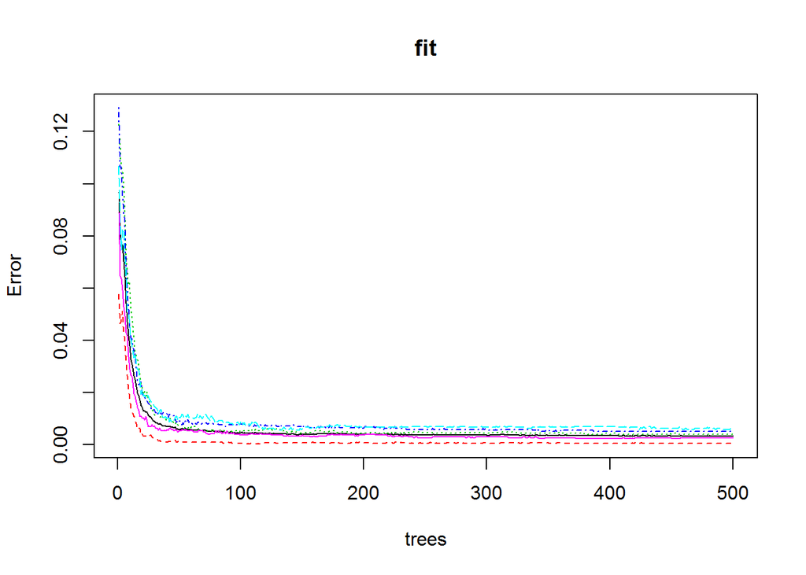

```r
plot(fit)
```